# R Notebook

Dandara Sousa

Hugo Silva

Lorena Pereira

```r
climas = read_csv(here::here("data/clima_cg_jp-semanal.csv"),
                  col_types = "cTdddddd")

climas <- climas %>%
    mutate(mes_abrev = factor(month.abb[mes], month.abb))
```

**Nota: A análise será feita a partir do ano de 2002 para evitar a falta de dados dos anos anteriores.**

### 1 - Qual foi o São João mais frio de CG que está nos nossos dados?

Filtrando os dados para apenas a cidade de Campina Grande no período entre 18 e 24 de junho (a semana do São João) , o São João mais frio é aquele onde a temperatura mínima semanal foi a menor de todas. Para este caso, observando anualmente é visto 2018 teve esse marco com temperatura mínima de **16.6°**. A temperatura mínima média dessa época é de 17.99°.

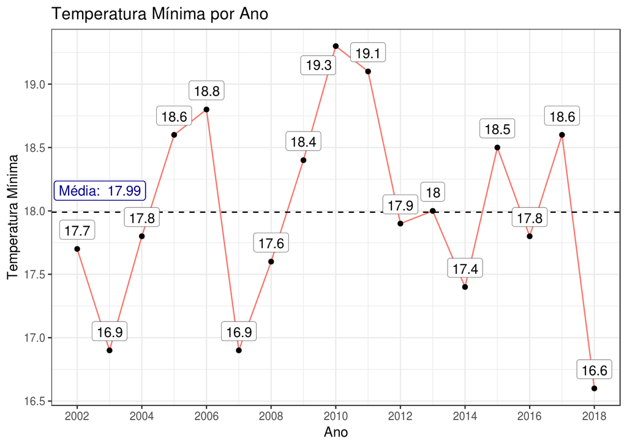

```r
clima_sj <- climas %>%
  filter(ano >= 2002 & ano <= 2018)  %>%
  filter(cidade == "Campina Grande" & mes == 6 & day(as.Date(semana)) >= 18 & day(as.Date(semana)) <=24)

temp_sj <- clima_sj$tmin %>% mean() %>% round(2)

clima_sj %>%
  ggplot(aes(ano,tmin, label=tmin)) +
  geom_line(aes(color=cidade)) +
  geom_point() +
  geom_hline(yintercept = temp_sj, linetype='dashed') +
  geom_label(aes(x=2002.7, y=temp_sj+.17, label=paste("Média: ", temp_sj)), color="darkblue") +
  geom_label(label.size=0.1,
             hjust=c(0.5, 0.5, 0.5, 0.5, 0.5, 0.5, 0.5, 0.5, 1, 0.5, 0.5, 0.5, 0.5, 0.5, 0.5, 0.5, 0.5),
             vjust=c(-0.5, -0.5, -0.5, -0.5, -0.5, -0.5, -0.5, -0.5, 1.5, -0.5, -0.5, -0.5, -0.5, -0.5, -0.5, -0.5, -0.5)) +
  scale_x_continuous(breaks = seq(2002,2018,2)) +
  scale_y_continuous(breaks = seq(16,25,0.5)) +
  labs(x = "Ano", y = "Temperatura Mínima", title="Temperatura Mínima por Ano") +
  theme(legend.position = "none")
```

### 2 - A distribuição é diferente em meses específicos?

No geral a quantidade de chuva não se mantém constante durante os anos. Utilizando o índice pluviométrico médio pode-se observar que o mês com maior quantidade de chuva é **Junho** para ambas as cidades. E o mês com menos chuva é **Novembro**, também para ambas as cidades.

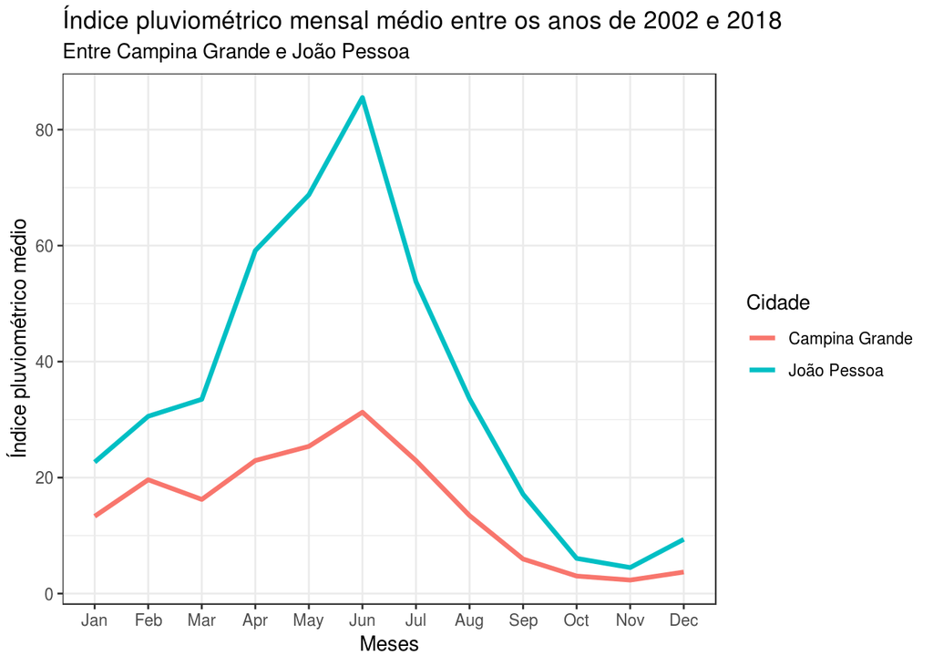

```r
climas_qt = climas %>% dplyr::select(mes, mes_abrev, tmedia, tmax, tmin, chuva, cidade, ano)

media_por_mes_todos_os_anos = climas_qt %>%
                filter(ano > 2001 & ano < 2019)  %>%
                group_by(mes_abrev, cidade) %>%
                summarise(mean_tmax = mean(x=tmax), mean_tmedia = mean(x=tmedia), mean_chuva = mean(x=chuva))

ggplot(data = media_por_mes_todos_os_anos, mapping = aes(x = mes_abrev, y = mean_chuva)) +
                geom_line(aes(col=cidade, group=cidade), size=1.2) +
                ggtitle("Índice pluviométrico mensal médio entre os anos de 2002 e 2018",
                        subtitle="Entre Campina Grande e João Pessoa") +
                labs(x="Meses", y="Índice pluviométrico médio", colour = "Cidade")
```

### 3 - Como estão distribuídas as amplitudes de temperatura entre 2002 e 2018?

O gráfico abaixo apresenta um boxplot com os dados de temperatura média de cada mês em cada ano.

Observando a distribuição das temperaturas médias ao longo dos anos é possível identificar que o ano de 2016 teve menor amplitude e apresentou as temperaturas ao longo dos meses de forma mais simétrica.

Já os anos de 2008 e 2017 tiveram maior amplitude, sendo que dentre todos os anos 2017 apresentou a menor temperatura já registrada nesse intervalo.

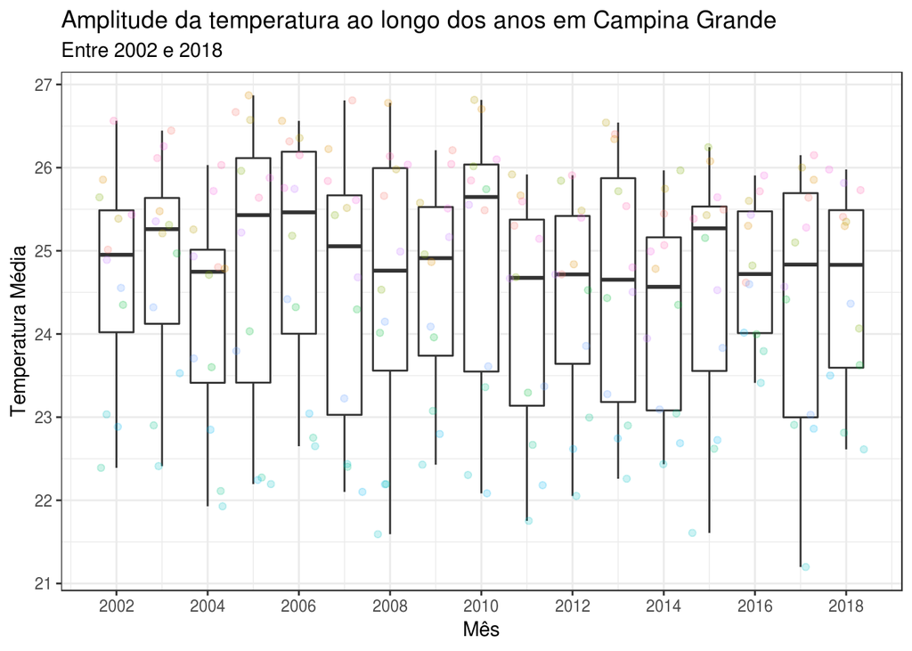

```r
amplitude = climas_qt %>%
                filter(ano > 2001 & ano < 2019 & cidade == "Campina Grande")  %>%
                group_by(ano, mes_abrev, cidade) %>%
                summarise(mean_tmax = mean(x=tmax), mean_tmin = mean(x=tmin), mean_tmedia = mean(x=tmedia))

amplitude %>%
    ggplot(aes(x=ano, y=mean_tmedia, group=ano)) +
    geom_boxplot() +
    geom_jitter(alpha=0.2, aes(color=mes_abrev)) +
    ggtitle("Amplitude da temperatura ao longo dos anos em Campina Grande", subtitle="Entre 2002 e 2018") +
    xlab("Mês") +
    ylab("Temperatura Média") +
    theme(legend.position = "none") +
    scale_x_continuous(breaks = seq(2002,2018,2))
```